# Biostatistics project - Group 25

Emma Van Kerckhove, Kylian Baeyens, Robbe Claeys, Tom Nissens

2022-2023

# BASTA Strawberry Trial 2022

The biostatistics course project is based on the BASTA research (Biochar’s Added value) organised by ILVO, UHasselt and pcfruit.

Biochar is the residual product formed after pyrolysis of biomass and has currently no economic value. In this project researchers are interested to see if (1) Biochar can partly replace peat and (2) Biochar can be used to promote plant development and/or plant disease resistance of strawberry.

**Variables:**

- the type of growing medium (peat, peat_biochar, peatfree, peatfree_biochar)
- the addition of biochar as a vaccine (vaccine 1-3)
- the addition of *Trichoderma* (*Trichoderma* 1-3)

**Measurements:**

- root rot score (30, 50, and 80 days after infection)
- total number of fruits over 15 plants
- number of fruits infected with *Botrytis* (after harvest, one week storage at 6°C, and three days storage at 20°C)
- weight of strawberries per plant in kg (class 1, class 2, curved, and total strawberries)
- fresh biomass per plant
- dry biomass per plant

**Research question:**  
On average, is there an effect of growing medium and/or the addition of Trichoderma on the weight of the curved strawberries. (data set 2)

# Data Preparation

## Load the libraries

```r
library(tidyverse)
library(car)
library(multcomp)
library(SummarizedExperiment)
library(edgeR)
library(pwr)
```

## Read the data

```r
data <- read.delim(
  "data/BASTA_Dataset2_Trichoderma.txt",
  header = TRUE, stringsAsFactors = FALSE, quote = "", sep = "\t")
head(data)
```

|  | SampleName | Replicates | Plot_Greenhouse | Greenhouse | Substrate | Peat | Yes | Vaccine | Trichoderma | rootrot1 | rootrot2 | rootrot3 | TotalNr_Fruits | BC_harvest | BC_Storage_1 | BC_Storage_2 | Class1_strawberries | Class2_strawberries | Curved_strawberries | Total_strawberry_weight | Fresh_Biomass | Dry_Biomass |
| --- | --- | --- | --- | --- | --- | --- | --- | --- | --- | --- | --- | --- | --- | --- | --- | --- | --- | --- | --- | --- | --- | --- |
| 1 | BA3_201_P_0_1 | 1 | 1J | 1 | Peat | Peat | No | None | None | 0.0 | 11.5 | 37.0 | 130 | 5 | 9 | 72 | 0.07800000 | 0.05385714 | 0.001642857 | 0.1362143 | 132 | 31.2 |
| 2 | BA3_201_P_0_2 | 2 | 3Q | 1 | Peat | Peat | No | None | None | 5.0 | 18.5 | 61.0 | 127 | 5 | 16 | 86 | 0.08400000 | 0.07228571 | 0.006857143 | 0.1803571 | 204 | 51.9 |
| 3 | BA3_201_P_0_3 | 3 | 5M | 2 | Peat | Peat | No | None | None | 2.0 | 12.5 | 25.0 | 195 | 11 | 34 | 81 | 0.09578571 | 0.14464286 | 0.012071429 | 0.2525000 | 168 | 39.9 |
| 4 | BA3_201_P_0_4 | 4 | 6A | 2 | Peat | Peat | No | None | None | 3.5 | 21.5 | 33.0 | 135 | 5 | 10 | 92 | 0.09261538 | 0.07453846 | 0.012615385 | 0.1857692 | 165 | 40.7 |
| 5 | BA3_205_P_0a_1 | 1 | 2K | 2 | Peat | Peat | No | None | Trich1 | 20.5 | 20.5 | 30.5 | 197 | 10 | 28 | 150 | 0.14184615 | 0.10338461 | 0.018384615 | 0.2798462 | 148 | 34.1 |
| 6 | BA3_205_P_0a_2 | 2 | 3F | 2 | Peat | Peat | No | None | Trich1 | 3.5 | 31.0 | 42.0 | 141 | 2 | 15 | 101 | 0.12350000 | 0.07100000 | 0.001500000 | 0.2144167 | 60 | 13.8 |

# Research Investigation

## Variables

**Response variable:** The weight of the curved strawberries: Curved_strawberries

**Explanatory variable(s):**

- Growing medium (peat/non-peat and biochar/ no biochar): Substrate
- Addition of *Trichoderma*: Trichoderma
- Greenhouse: Greenhouse

**Observational unit:** The strawberry plant.

**Experimental unit:** Three trays of 5 plants.

## Hypotheses

**H01**: On average, the growing medium has no effect on the weight of the curved strawberries.

**H02**: On average, the addition of *Trichoderma* has no effect on the weight of the curved strawberries.

**H03**: The effect of *Trichoderma* addition on the weight of the curved strawberries does not differ for the different growth media.

**Ha1**: On average, the growing medium has an effect on the weight of the curved strawberries.

**Ha2**: On average, the addition of *Trichoderma* has an effect on the weight of the curved strawberries.

**Ha3**: The effect of *Trichoderma* addition on the weight of the curved strawberries differs for the different growth media.

# Data Exploration

First we filter the data, generate an appropriate format, and provide some basic statistics.

```r
df <- data.frame(data[,c(1, 4:5, 9, 19)])
df$Greenhouse <- factor(df$Greenhouse)
df$Trichoderma <- factor(df$Trichoderma)
df$Substrate <- factor(df$Substrate)

head(df)
```

|  | SampleName | Greenhouse | Substrate | Trichoderma | Curved_strawberries |
| --- | --- | --- | --- | --- | --- |
| 1 | BA3_201_P_0_1 | 1 | Peat | None | 0.001642857 |
| 2 | BA3_201_P_0_2 | 1 | Peat | None | 0.006857143 |
| 3 | BA3_201_P_0_3 | 2 | Peat | None | 0.012071429 |
| 4 | BA3_201_P_0_4 | 2 | Peat | None | 0.012615385 |
| 5 | BA3_205_P_0a_1 | 2 | Peat | Trich1 | 0.018384615 |
| 6 | BA3_205_P_0a_2 | 2 | Peat | Trich1 | 0.001500000 |

```r
summary(df)
```

```
##   SampleName        Greenhouse            Substrate  Trichoderma
##  Length:64          1:31       Peat            :16   None  :16
##  Class :character   2:33       Peat_Biochar    :16   Trich1:16
##  Mode  :character              Peatfree        :16   Trich2:16
##                                Peatfree_Biochar:16   Trich3:16
##
##
##  Curved_strawberries
##  Min.   :0.000000
##  1st Qu.:0.007495
##  Median :0.012036
##  Mean   :0.013393
##  3rd Qu.:0.016932
##  Max.   :0.042000
```

Next, some basic plots are generated to provide an initial intuitive view on the effects of the explanatory variables.

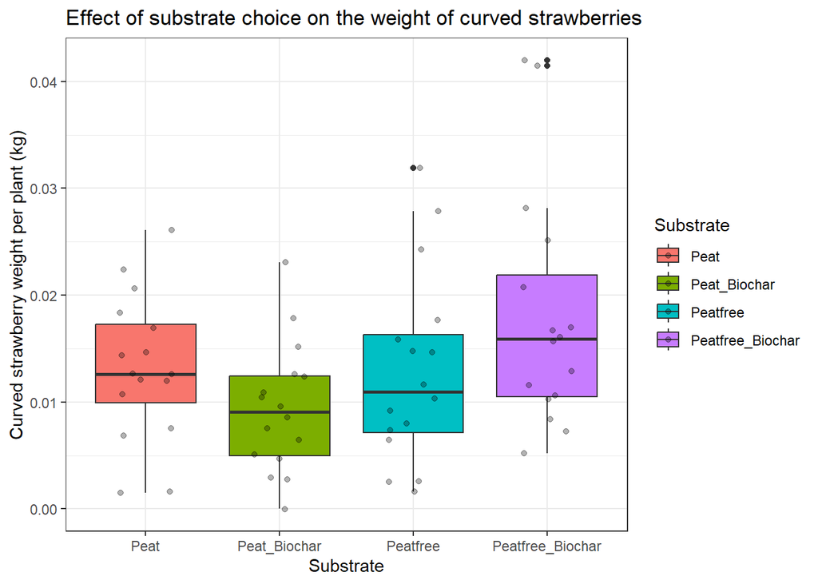

```r
# plots effect of substrate choice
df %>%
  ggplot(aes(x = Substrate, y = Curved_strawberries, fill = Substrate)) +
  geom_boxplot() +
  labs(
    title = "Effect of substrate choice on the weight of curved strawberries",
    y = "Curved strawberry weight per plant (kg)") +
  geom_jitter(width = 0.2, alpha = 0.3) +
  theme_bw()
```

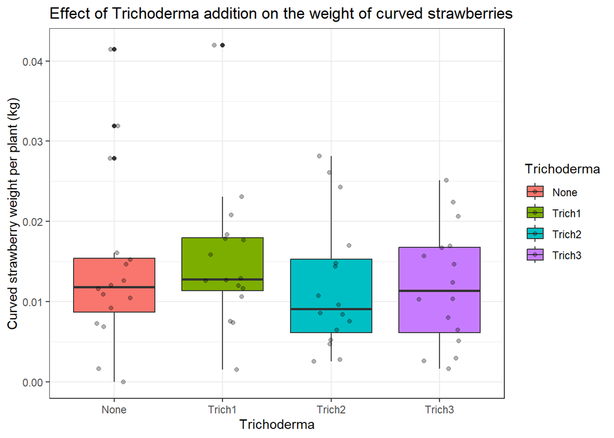

```r
# plots effect of Trichoderma addition
df %>%
  ggplot(aes(x = Trichoderma, y = Curved_strawberries, fill = Trichoderma)) +
  geom_boxplot() +
  labs(
    title = "Effect of Trichoderma addition on the weight of curved strawberries",
    y = "Curved strawberry weight per plant (kg)") +
  geom_jitter(width = 0.2, alpha = 0.3) +
  theme_bw()
```

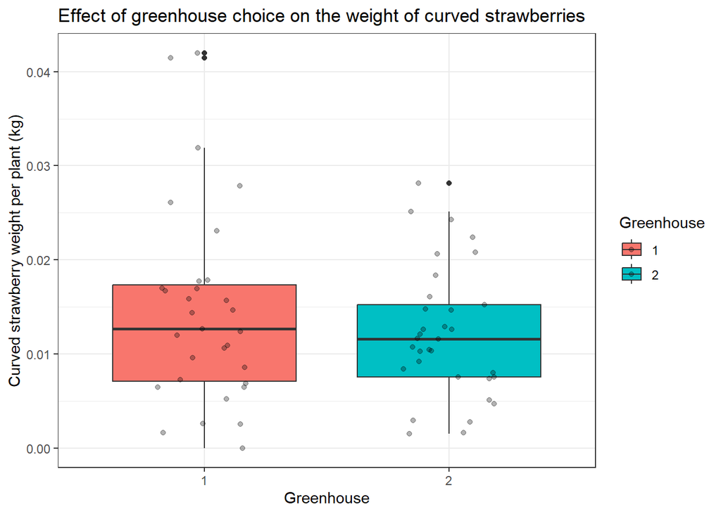

```r
# plots effect of greenhouse choice
df %>%
  ggplot(aes(x = Greenhouse, y = Curved_strawberries, fill = Greenhouse)) +
  geom_boxplot() +
  labs(
    title = "Effect of greenhouse choice on the weight of curved strawberries",
    y = "Curved strawberry weight per plant (kg)") +
  geom_jitter(width = 0.2, alpha = 0.3) +
  theme_bw()
```

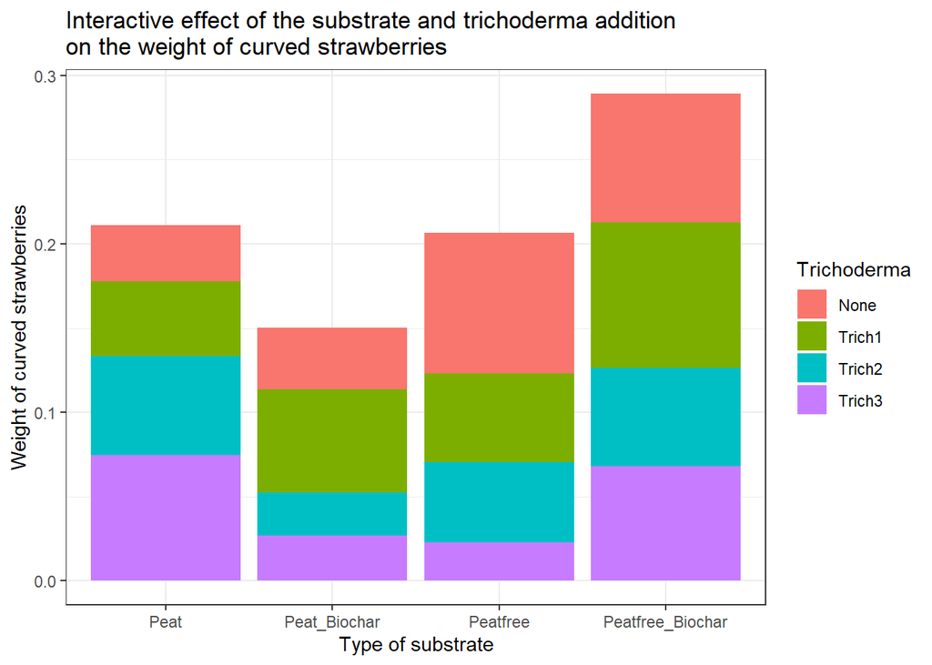

```r
# bar chart to check for possible interactivity between variables
df %>%
  filter(Trichoderma %in% c("None","Trich1","Trich2","Trich3")) %>%
  ggplot(aes(x = Substrate, y = Curved_strawberries, fill = Trichoderma)) +
  geom_bar(stat = "identity") +
       labs(
         title = "Interactive effect of the substrate and trichoderma addition\non the weight of curved strawberries",
         x = "Type of substrate",
         y = "Weight of curved strawberries") +
  theme_bw()
```

To investigate further, a plot was generated that distinguishes between the substrate choice & *Trichoderma* addition effects. This leads to believe that the effects of both explanatory variables are linked.

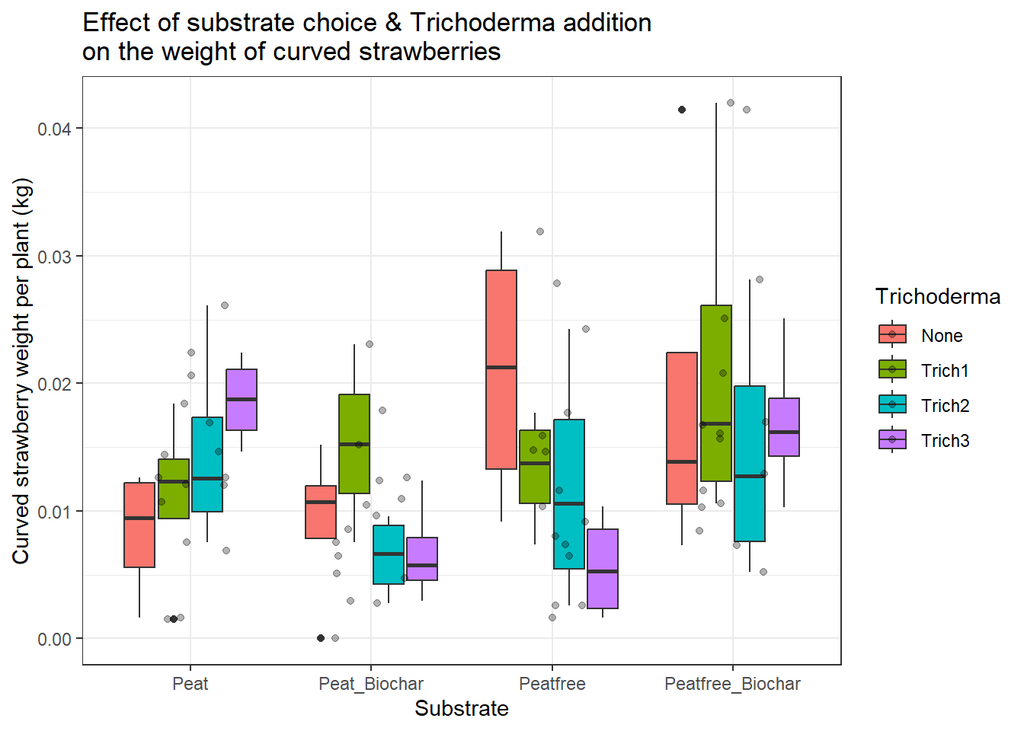

```r
# plots effect of substrate choice & Trichoderma addition
df %>%
  filter(Trichoderma %in% c("None","Trich1","Trich2","Trich3")) %>%
  ggplot(aes(x = Substrate, y = Curved_strawberries, fill = Trichoderma)) +
  geom_boxplot() +
    labs(
    title = "Effect of substrate choice & Trichoderma addition\non the weight of curved strawberries",
    y = "Curved strawberry weight per plant (kg)") +
  geom_jitter(width = 0.2, alpha = 0.3) +
  theme_bw()
```

Due to the limited number of observations and the large number of variables, trends in these plots should not be taken for granted and further statistical investigation will be performed.

# Model Selection & Statisticial Inference

## Assumption checking

To check normality, histograms & QQ-plots are generated.

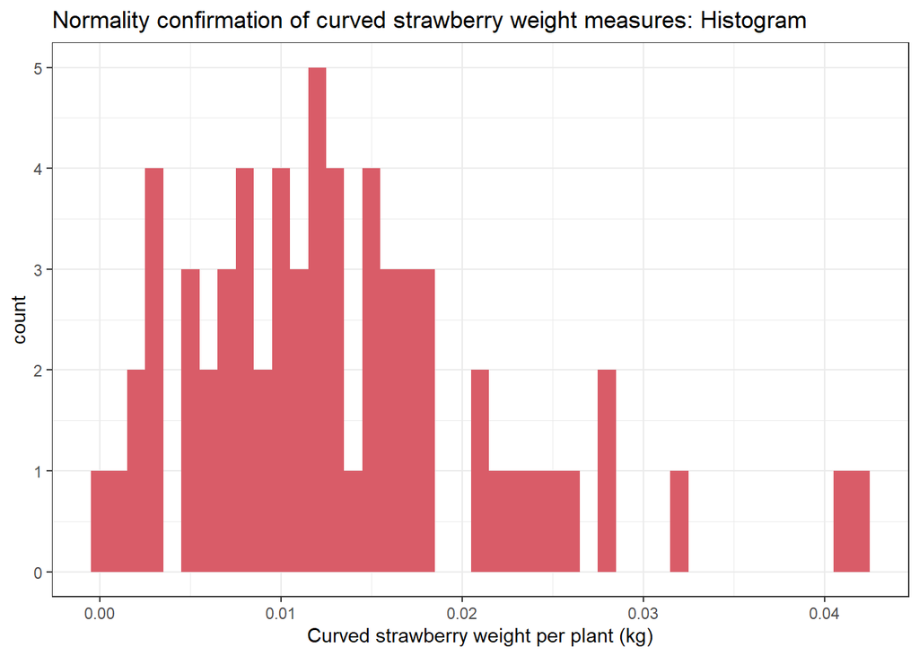

```r
df %>%
  ggplot(aes(x = Curved_strawberries)) +
  geom_histogram(fill = "#D95C68", binwidth = 0.001) +
      labs(
    title = "Normality confirmation of curved strawberry weight measures: Histogram",
    x = "Curved strawberry weight per plant (kg)") +
  theme_bw()
```

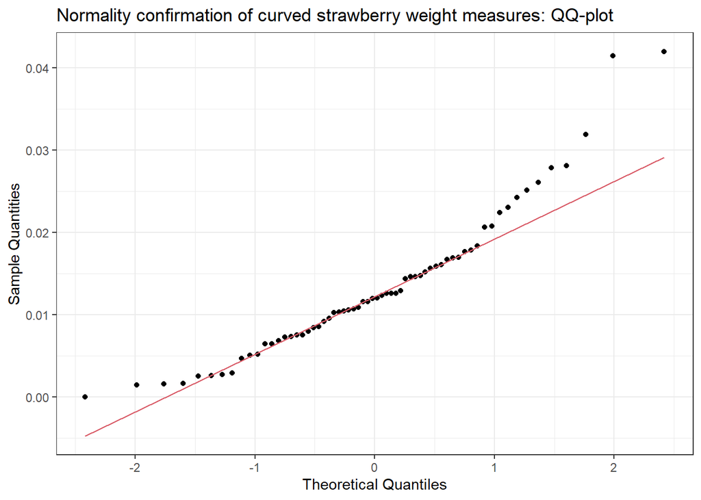

```r
df %>%
  ggplot(aes(sample = Curved_strawberries)) +
  stat_qq() +
  stat_qq_line(col = "#D95C68") +
  labs(
    title = "Normality confirmation of curved strawberry weight measures: QQ-plot",
    x = "Theoretical Quantiles",
    y = "Sample Quantities") +
  theme_bw()
```

The data are not normally distributed, has a lower bound of zero, and a tail to the right can be observed. A square root-transformation might help to make the data more normally distributed. The assumptions are re-evaluated.

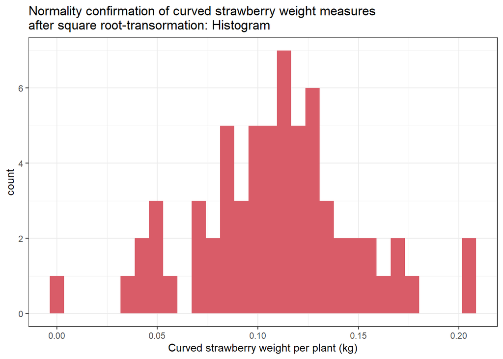

```r
df_t <- df
df_t$Curved_strawberries <- ((df_t$Curved_strawberries)^0.5)

df_t %>%
  ggplot(aes(x = Curved_strawberries)) +
  geom_histogram(fill = "#D95C68") +
      labs(
    title = "Normality confirmation of curved strawberry weight measures\nafter square root-transormation: Histogram",
    x = "Curved strawberry weight per plant (kg)") +
  theme_bw()
```

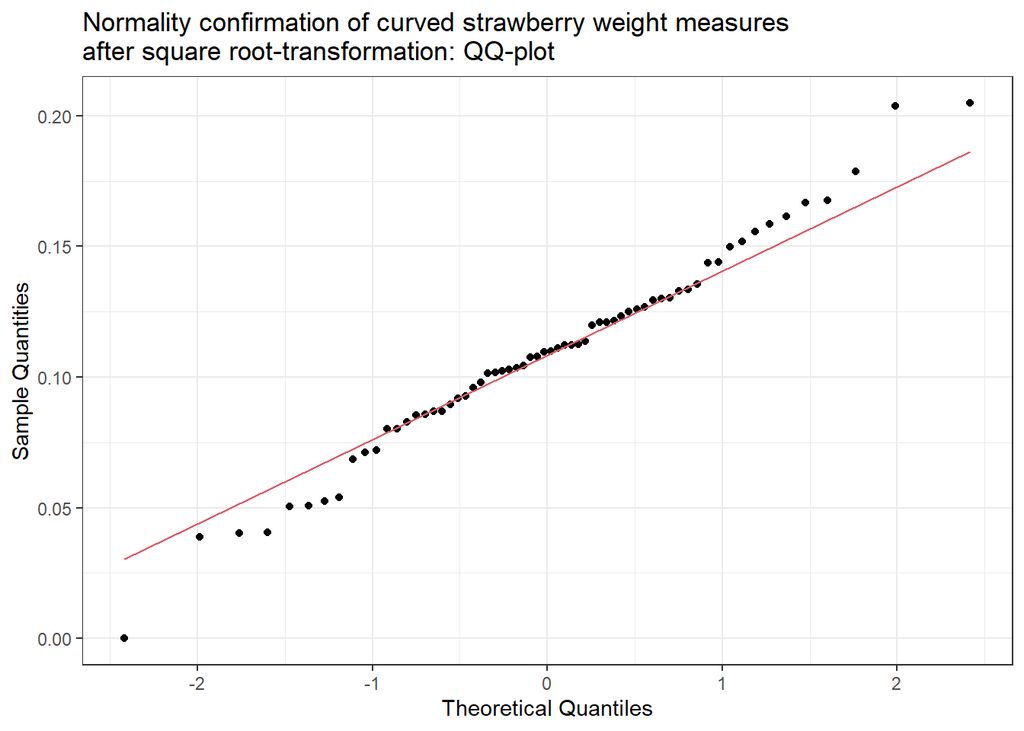

```r
df_t %>%
  ggplot(aes(sample = Curved_strawberries)) +
  stat_qq() +
  stat_qq_line(col = "#D95C68") +
  labs(
    title = "Normality confirmation of curved strawberry weight measures\nafter square root-transformation: QQ-plot",
    x = "Theoretical Quantiles",
    y = "Sample Quantities") +
  theme_bw()
```

A square root transformation has a beneficial effect on the normality of the data, the departures from normality are also symmetric. Back-transformation will have to be performed during model interpretation. It was noticed however, that there is an observation where the weight of curved strawberries is zero. This value doesn’t hinder further analysis and is still taken into account.

Although homoscedasticity seems to be met (based on the previously shown box plots), an additional sanity check is performed with Levene’s test (which is robust against normality violations). If the resulting p-value is greater than 0.05, the null-hypothesis cannot be rejected - meaning that sample variance is likely to have occurred based on random sampling from a population with equal variances.

```r
leveneTest(
  Curved_strawberries ~ interaction(Substrate, Trichoderma),
  data = df_t)
```

|  | Df | F value | Pr(>F) |
| --- | --- | --- | --- |
| group | 15 | 0.5113896 | 0.9220524 |
|  | 48 | NA | NA |

## Model fitting

A model is generated with substrate-choice, *Trichoderma*-addition, and an interaction variable between both as explanatory variables.

```r
# set peatfree as intercept (peatfree is control soil)
df_t <- within(df_t, Substrate <- relevel(Substrate, ref = "Peatfree"))

fit1 = lm(
  Curved_strawberries ~ Substrate + Trichoderma + Substrate:Trichoderma,
  data = df_t)

summary(fit1)
```

```
##
## Call:
## lm(formula = Curved_strawberries ~ Substrate + Trichoderma +
##     Substrate:Trichoderma, data = df_t)
##
## Residuals:
##       Min        1Q    Median        3Q       Max
## -0.082513 -0.024093  0.000912  0.020494  0.072717
##
## Coefficients:
##                                              Estimate Std. Error t value
## (Intercept)                                  0.140601   0.018125   7.757
## SubstratePeat                               -0.054219   0.025633  -2.115
## SubstratePeat_Biochar                       -0.058088   0.025633  -2.266
## SubstratePeatfree_Biochar                   -0.009714   0.025633  -0.379
## TrichodermaTrich1                           -0.027434   0.025633  -1.070
## TrichodermaTrich2                           -0.038566   0.025633  -1.505
## TrichodermaTrich3                           -0.070073   0.025633  -2.734
## SubstratePeat:TrichodermaTrich1              0.040128   0.036250   1.107
## SubstratePeat_Biochar:TrichodermaTrich1      0.066060   0.036250   1.822
## SubstratePeatfree_Biochar:TrichodermaTrich1  0.037962   0.036250   1.047
## SubstratePeat:TrichodermaTrich2              0.070158   0.036250   1.935
## SubstratePeat_Biochar:TrichodermaTrich2      0.034031   0.036250   0.939
## SubstratePeatfree_Biochar:TrichodermaTrich2  0.023165   0.036250   0.639
## SubstratePeat:TrichodermaTrich3              0.119825   0.036250   3.306
## SubstratePeat_Biochar:TrichodermaTrich3      0.066768   0.036250   1.842
## SubstratePeatfree_Biochar:TrichodermaTrich3  0.067765   0.036250   1.869
##                                             Pr(>|t|)
## (Intercept)                                 5.13e-10 ***
## SubstratePeat                                0.03963 *
## SubstratePeat_Biochar                        0.02799 *
## SubstratePeatfree_Biochar                    0.70638
## TrichodermaTrich1                            0.28985
## TrichodermaTrich2                            0.13898
## TrichodermaTrich3                            0.00874 **
## SubstratePeat:TrichodermaTrich1              0.27382
## SubstratePeat_Biochar:TrichodermaTrich1      0.07464 .
## SubstratePeatfree_Biochar:TrichodermaTrich1  0.30025
## SubstratePeat:TrichodermaTrich2              0.05885 .
## SubstratePeat_Biochar:TrichodermaTrich2      0.35255
## SubstratePeatfree_Biochar:TrichodermaTrich2  0.52584
## SubstratePeat:TrichodermaTrich3              0.00180 **
## SubstratePeat_Biochar:TrichodermaTrich3      0.07168 .
## SubstratePeatfree_Biochar:TrichodermaTrich3  0.06768 .
## ---
## Signif. codes:  0 '***' 0.001 '**' 0.01 '*' 0.05 '.' 0.1 ' ' 1
##
## Residual standard error: 0.03625 on 48 degrees of freedom
## Multiple R-squared:  0.3536, Adjusted R-squared:  0.1516
## F-statistic:  1.75 on 15 and 48 DF,  p-value: 0.07216
```

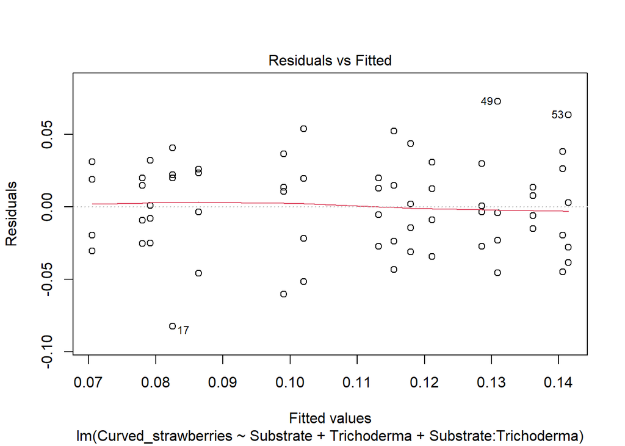

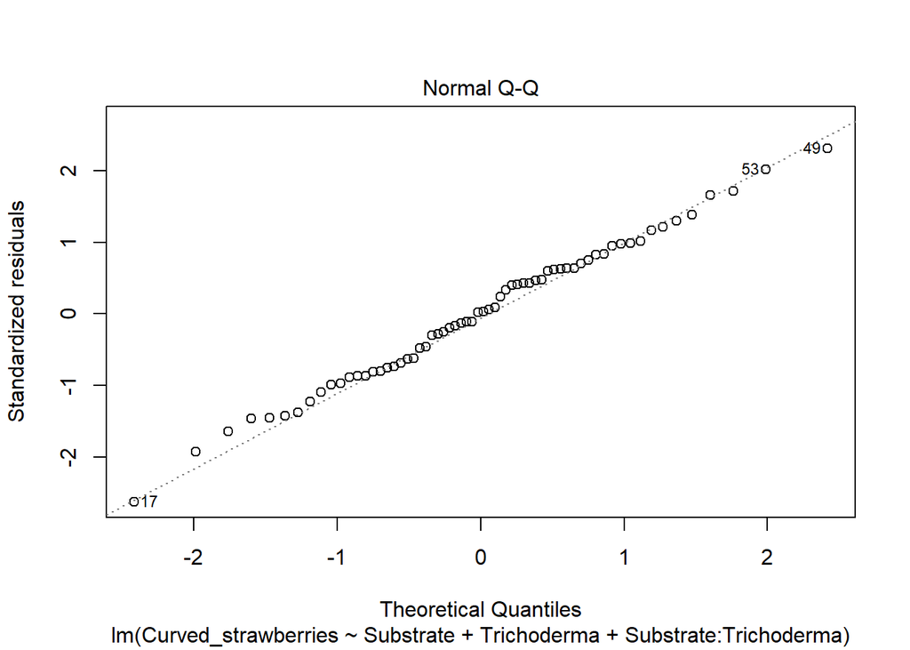

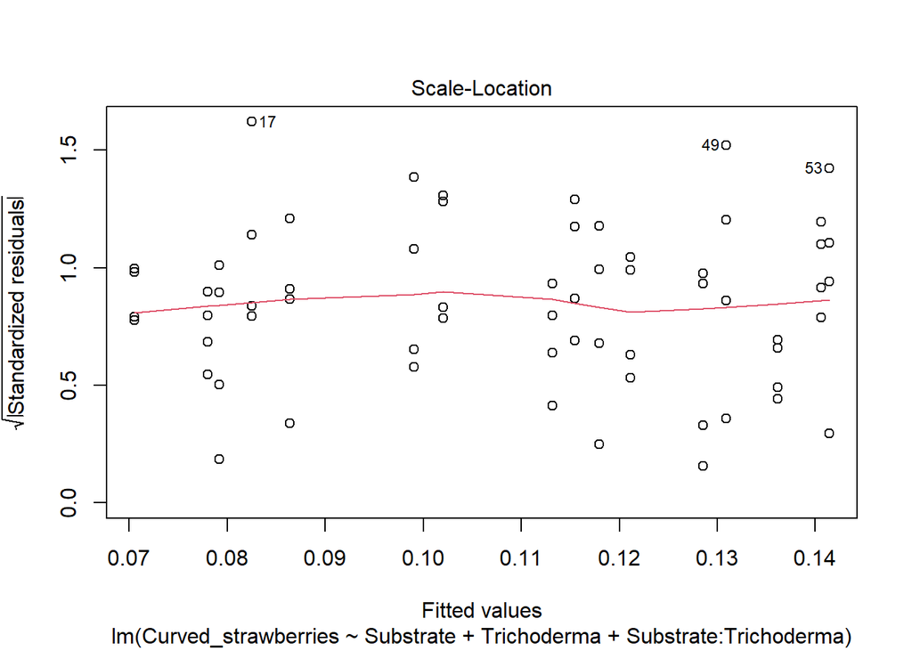

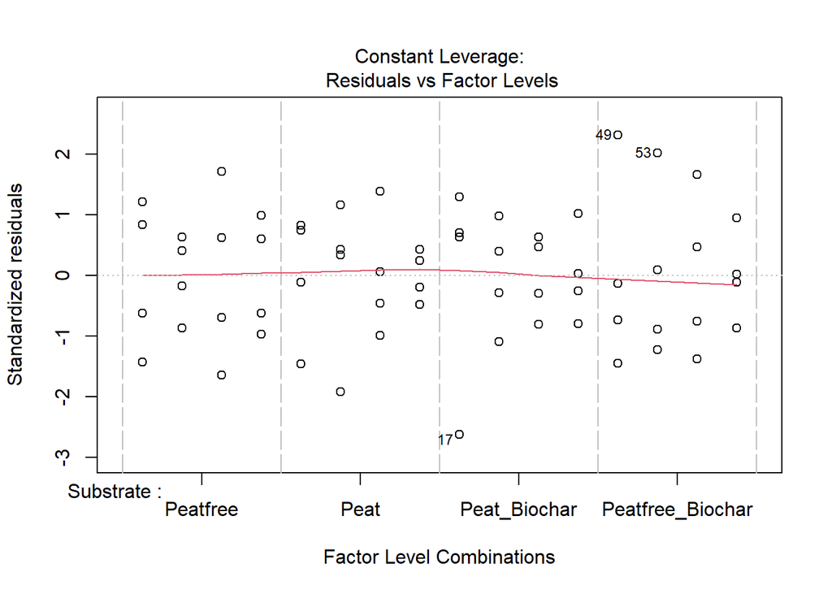

```r
plot(fit1)
```

The assumptions and testing plots show good results but no 5% significance is obtained for the overall model (p-value: 0.07216). Analysis of variance (ANOVA) is performed to check which variables best account for the variance present in the data.

```r
anova(fit1)
```

|  | Df | Sum Sq | Mean Sq | F value | Pr(>F) |
| --- | --- | --- | --- | --- | --- |
| Substrate | 3 | 0.012214294 | 0.0040714312 | 3.0983293 | 0.03538062 |
| Trichoderma | 3 | 0.002496088 | 0.0008320295 | 0.6331683 | 0.59724277 |
| Substrate:Trichoderma | 9 | 0.019791496 | 0.0021990551 | 1.6734648 | 0.12176244 |
| Residuals | 48 | 0.063075509 | 0.0013140731 | NA | NA |

When performing anova, only a significant result can be obtained for substrate as explanatory variable.

Additionaly, the variance inflation factor (VIF) for the fit can indicate whether there is multicollinearity between two or more variables.

```r
vif(fit1, type = "predictor")
```

```
## GVIFs computed for predictors
```

|  | GVIF | Df | GVIF^(1/(2*Df)) | Interacts With | Other Predictors |
| --- | --- | --- | --- | --- | --- |
| Substrate | 1 | 15 | 1 | Trichoderma | -- |
| Trichoderma | 1 | 15 | 1 | Substrate | -- |

The GVIF values (generalized VIF) indicate there is no correlation between the predictor variables in the model, therefore, all variables of fit1 are kept in the final model. Though a more simple model will also be investigated:

Linear model fit with only substrate as explanatory variable:

```r
fit2 <- lm(
  Curved_strawberries ~ Substrate,
  data = df_t)

summary(fit2)
```

```
##
## Call:
## lm(formula = Curved_strawberries ~ Substrate, data = df_t)
##
## Residuals:
##       Min        1Q    Median        3Q       Max
## -0.090209 -0.021904  0.000739  0.021247  0.075847
##
## Coefficients:
##                            Estimate Std. Error t value Pr(>|t|)
## (Intercept)                0.106583   0.009430  11.303   <2e-16 ***
## SubstratePeat              0.003309   0.013336   0.248   0.8049
## SubstratePeat_Biochar     -0.016373   0.013336  -1.228   0.2243
## SubstratePeatfree_Biochar  0.022509   0.013336   1.688   0.0966 .
## ---
## Signif. codes:  0 '***' 0.001 '**' 0.01 '*' 0.05 '.' 0.1 ' ' 1
##
## Residual standard error: 0.03772 on 60 degrees of freedom
## Multiple R-squared:  0.1252, Adjusted R-squared:  0.08143
## F-statistic: 2.862 on 3 and 60 DF,  p-value: 0.0442
```

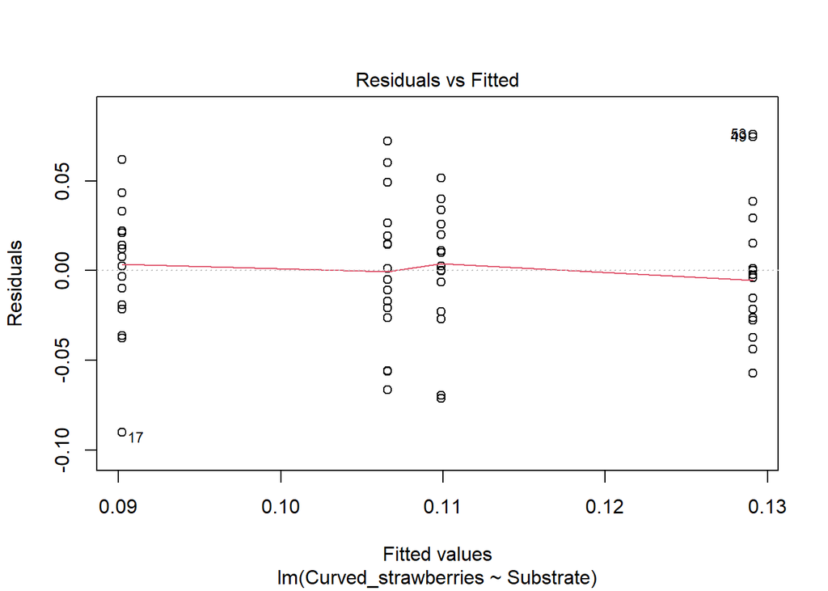

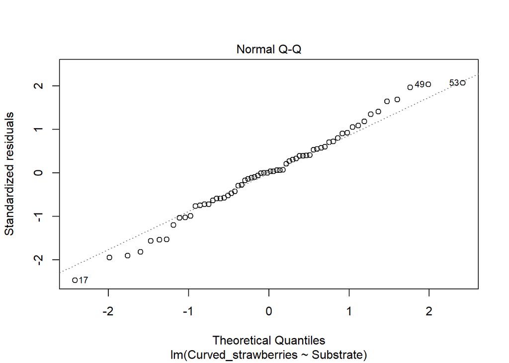

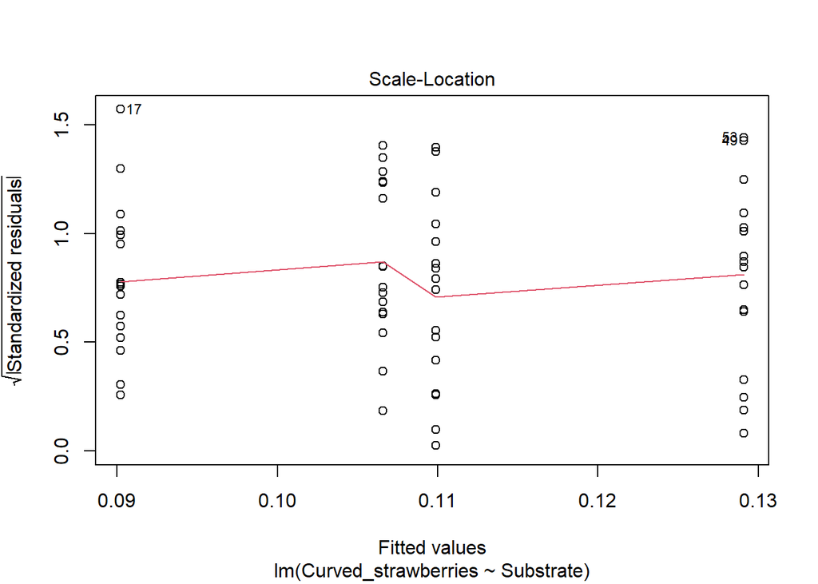

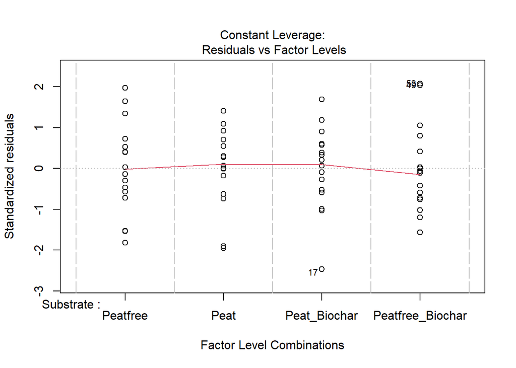

```r
plot(fit2)
```

### Blocking

The greenhouse choice could be responsible for technical variation present in the data. As the greenhouses can have a slightly different temperature, humidity, … Therefore, the greenhouse variable is incorporated in the model. (blocking)

```r
fit3 = lm(
  Curved_strawberries ~ Substrate + Trichoderma + Greenhouse + Substrate:Trichoderma,
  data = df_t)

summary(fit3)
```

```
##
## Call:
## lm(formula = Curved_strawberries ~ Substrate + Trichoderma +
##     Greenhouse + Substrate:Trichoderma, data = df_t)
##
## Residuals:
##      Min       1Q   Median       3Q      Max
## -0.08488 -0.02305 -0.00145  0.02186  0.07036
##
## Coefficients:
##                                              Estimate Std. Error t value
## (Intercept)                                  0.142963   0.018837   7.590
## SubstratePeat                               -0.054219   0.025832  -2.099
## SubstratePeat_Biochar                       -0.058088   0.025832  -2.249
## SubstratePeatfree_Biochar                   -0.009714   0.025832  -0.376
## TrichodermaTrich1                           -0.027434   0.025832  -1.062
## TrichodermaTrich2                           -0.038566   0.025832  -1.493
## TrichodermaTrich3                           -0.068892   0.025934  -2.656
## Greenhouse2                                 -0.004723   0.009205  -0.513
## SubstratePeat:TrichodermaTrich1              0.040128   0.036532   1.098
## SubstratePeat_Biochar:TrichodermaTrich1      0.066060   0.036532   1.808
## SubstratePeatfree_Biochar:TrichodermaTrich1  0.037962   0.036532   1.039
## SubstratePeat:TrichodermaTrich2              0.070158   0.036532   1.920
## SubstratePeat_Biochar:TrichodermaTrich2      0.034031   0.036532   0.932
## SubstratePeatfree_Biochar:TrichodermaTrich2  0.023165   0.036532   0.634
## SubstratePeat:TrichodermaTrich3              0.118645   0.036604   3.241
## SubstratePeat_Biochar:TrichodermaTrich3      0.065587   0.036604   1.792
## SubstratePeatfree_Biochar:TrichodermaTrich3  0.066585   0.036604   1.819
##                                             Pr(>|t|)
## (Intercept)                                 1.05e-09 ***
## SubstratePeat                                0.04122 *
## SubstratePeat_Biochar                        0.02926 *
## SubstratePeatfree_Biochar                    0.70857
## TrichodermaTrich1                            0.29365
## TrichodermaTrich2                            0.14212
## TrichodermaTrich3                            0.01075 *
## Greenhouse2                                  0.61026
## SubstratePeat:TrichodermaTrich1              0.27760
## SubstratePeat_Biochar:TrichodermaTrich1      0.07696 .
## SubstratePeatfree_Biochar:TrichodermaTrich1  0.30405
## SubstratePeat:TrichodermaTrich2              0.06088 .
## SubstratePeat_Biochar:TrichodermaTrich2      0.35633
## SubstratePeatfree_Biochar:TrichodermaTrich2  0.52909
## SubstratePeat:TrichodermaTrich3              0.00219 **
## SubstratePeat_Biochar:TrichodermaTrich3      0.07961 .
## SubstratePeatfree_Biochar:TrichodermaTrich3  0.07528 .
## ---
## Signif. codes:  0 '***' 0.001 '**' 0.01 '*' 0.05 '.' 0.1 ' ' 1
##
## Residual standard error: 0.03653 on 47 degrees of freedom
## Multiple R-squared:  0.3572, Adjusted R-squared:  0.1384
## F-statistic: 1.632 on 16 and 47 DF,  p-value: 0.09714
```

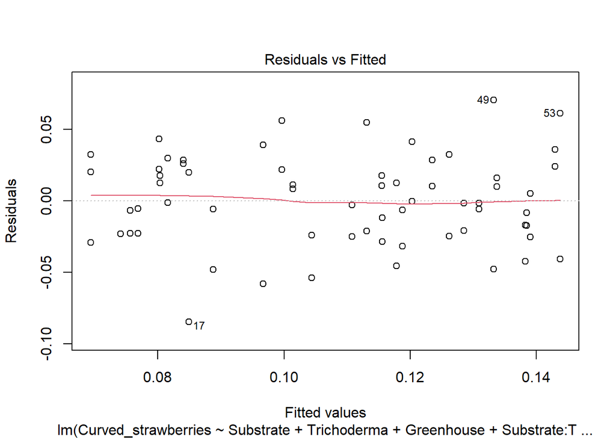

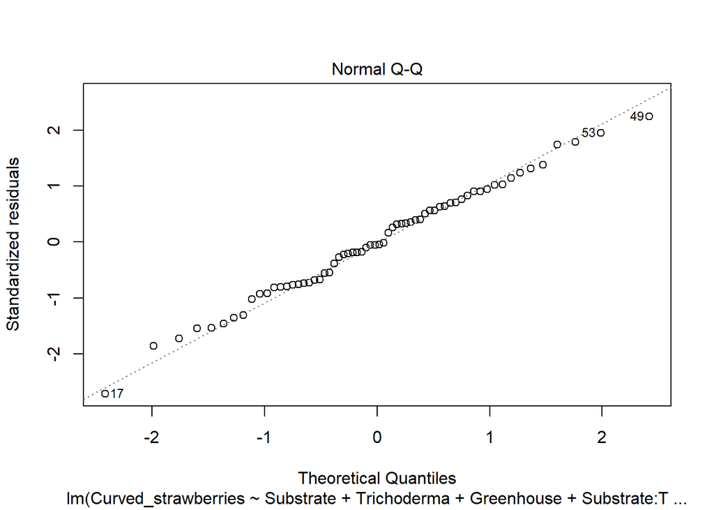

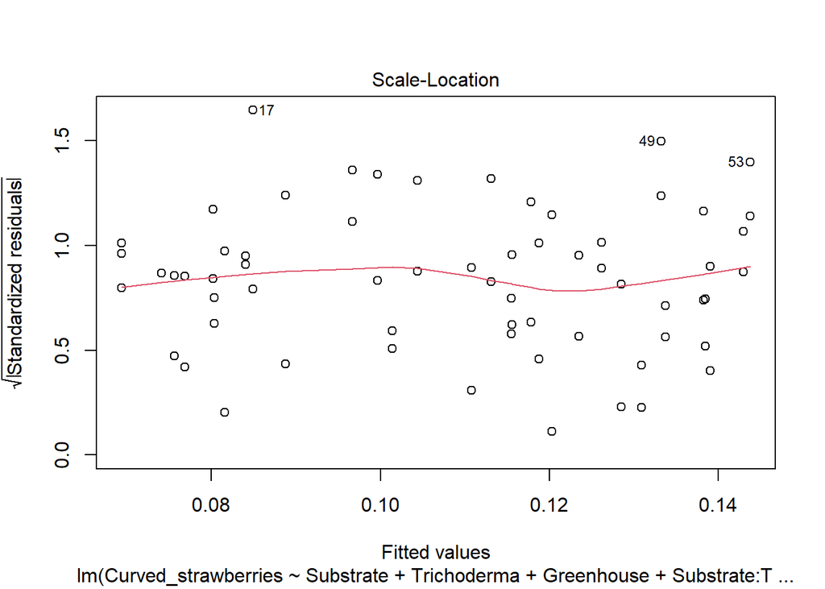

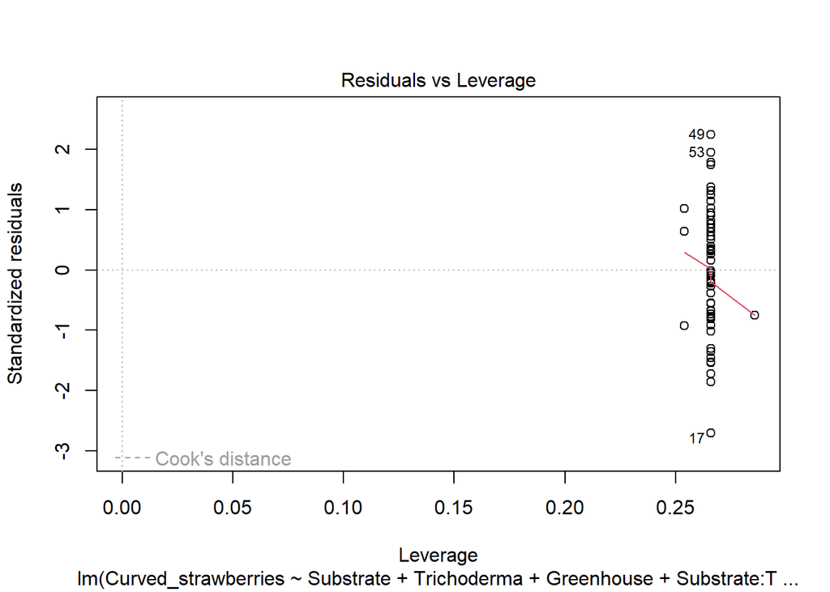

```r
plot(fit3)
```

The model produces less significant results when incorporating the greenhouse choice as a parameter (p-value: 0.09714 vs. 0.07216), but it is kept in the model in order to account for possible technical variation. Samples with Substrate:Peat and/or *Trichoderma*:Trich3 generate the most significant results, notably, the combination of both these variables shows a large difference in weight (before back-transformation).

Further statistical testing and pairwise comparison is performed, although the model isn’t significant.

```r
vif(fit3, type = "predictor")
```

```
## GVIFs computed for predictors
```

|  | GVIF | Df | GVIF^(1/(2*Df)) | Interacts With | Other Predictors |
| --- | --- | --- | --- | --- | --- |
| Substrate | 1.014881 | 15 | 1.000492 | Trichoderma | Greenhouse |
| Trichoderma | 1.014881 | 15 | 1.000492 | Substrate | Greenhouse |
| Greenhouse | 1.014881 | 1 | 1.007413 | -- | Substrate, Trichoderma |

The GVIF values are close to 1, indicating that there is no alarming correlation between any explanatory variables after adding the greenhouse variable.

```r
anova_fit3 <- aov(
  Curved_strawberries ~ Substrate + Trichoderma + Greenhouse + Substrate:Trichoderma,
  data = df_t)
summary(anova_fit3)
```

```
##                       Df  Sum Sq  Mean Sq F value Pr(>F)
## Substrate              3 0.01221 0.004071   3.051 0.0376 *
## Trichoderma            3 0.00250 0.000832   0.623 0.6034
## Greenhouse             1 0.00070 0.000695   0.521 0.4740
## Substrate:Trichoderma  9 0.01945 0.002161   1.619 0.1373
## Residuals             47 0.06272 0.001335
## ---
## Signif. codes:  0 '***' 0.001 '**' 0.01 '*' 0.05 '.' 0.1 ' ' 1
```

When performing an ANOVA test, it can be observed that there is only a significant difference when comparing different substrates. A Tukey post-hoc analysis is performed to compare the different substrates.

```r
Tukey_fit3 <- TukeyHSD(anova_fit3, which = "Substrate")
Tukey_fit3
```

```
##   Tukey multiple comparisons of means
##     95% family-wise confidence level
##
## Fit: aov(formula = Curved_strawberries ~ Substrate + Trichoderma + Greenhouse + Substrate:Trichoderma, data = df_t)
##
## $Substrate
##                                      diff         lwr        upr     p adj
## Peat-Peatfree                  0.00330878 -0.03109118 0.03770874 0.9940236
## Peat_Biochar-Peatfree         -0.01637347 -0.05077344 0.01802649 0.5876900
## Peatfree_Biochar-Peatfree      0.02250896 -0.01189100 0.05690892 0.3136637
## Peat_Biochar-Peat             -0.01968225 -0.05408222 0.01471771 0.4316803
## Peatfree_Biochar-Peat          0.01920018 -0.01519978 0.05360014 0.4535474
## Peatfree_Biochar-Peat_Biochar  0.03888243  0.00448247 0.07328240 0.0210655
```

It can be concluded that only a significant difference in weight of curved strawberries can be found when comparing the substrates *peatfree-biochar* & *peat-biochar* (p-value = 0,021).

The results are back-transformed for interpretation on the original scale.

For the Substrate Tukey-test:

```r
# Peatfree_Biochar-Peat_Biochar
# back-transform sqrt & convert kg -> g & sign
data.frame(
  abs(Tukey_fit3$Substrate[,1:3]) ^ 2 * 1000 * sign(Tukey_fit3$Substrate[,1:3])
  )
```

|  | diff | lwr | upr |
| --- | --- | --- | --- |
| Peat-Peatfree | 0.01094803 | -0.96666164 | 1.4219493 |
| Peat_Biochar-Peatfree | -0.26809065 | -2.57794187 | 0.3249543 |
| Peatfree_Biochar-Peatfree | 0.50665321 | -0.14139598 | 3.2386253 |
| Peat_Biochar-Peat | -0.38739112 | -2.92488617 | 0.2166109 |
| Peatfree_Biochar-Peat | 0.36864685 | -0.23103345 | 2.8729751 |
| Peatfree_Biochar-Peat_Biochar | 1.51184354 | 0.02009253 | 5.3703094 |

For the significant variables in the overall fit:

```r
dim(summary(fit3)$coefficients)
```

```
## [1] 17  4
```

```r
# columns: Estimate Std. Error    t value     Pr(>|t|)
data.frame(
  Estimate = abs(summary(fit3)$coefficients[,1]
              [summary(fit3)$coefficients[,4] < 0.05]) ^ 2 * 1000 * sign(
                (summary(fit3)$coefficients[,1]
                 [summary(fit3)$coefficients[,4] < 0.05])),

  Conf.Int = abs(confint(fit3)
              [summary(fit3)$coefficients[,4] < 0.05,]) ^ 2 * 1000 * sign(
                (confint(fit3)
                 [summary(fit3)$coefficients[,4] < 0.05,])
              )
)
```

|  | Estimate | Conf.Int.2.5.. | Conf.Int.97.5.. |
| --- | --- | --- | --- |
| (Intercept) | 20.438429 | 11.039374 | 32.70948632 |
| SubstratePeat | -2.939724 | -11.275453 | -0.00507376 |
| SubstratePeat_Biochar | -3.374227 | -12.112063 | -0.03747134 |
| TrichodermaTrich3 | -4.746096 | -14.656599 | -0.27953792 |
| SubstratePeat:TrichodermaTrich3 | 14.076547 | 2.025622 | 36.97249586 |

Some of the variable (combinations) show to have an effect on the weight of curved strawberries, especially the Peat:Trich3 interaction, though the confidence intervals are very broad.

The lack of significant findings could be due to a lack of power. A power analysis is performed.

```r
pwr.f2.test(u = 4, v = 64-4-1, f2 = 0.1384/(1-0.1384), sig.level = 0.05, power = NULL)
```

```
##
##      Multiple regression power calculation
##
##               u = 4
##               v = 59
##              f2 = 0.1606314
##       sig.level = 0.05
##           power = 0.6900734
```

The power of the linear model is 69%. This indicates that there is a 69% probability of not making a type 2 error. This could be improved by repeating the experiment with more samples. Next, we determine the amount of samples that should be taken to improve power to 80%.

```r
pwr.f2.test(u = 4, v = NULL, f2 = 0.1384/(1-0.1384), sig.level = 0.05, power = 0.8)
```

```
##
##      Multiple regression power calculation
##
##               u = 4
##               v = 74.19301
##              f2 = 0.1606314
##       sig.level = 0.05
##           power = 0.8
```

To improve the power of our model to 80%, at least 80 samples would have to be taken.

# Conclusion

No lineair model was found that showed significant results when accounting for the greenhouse choice. The assumptions to use a lineair model were met (normality, homoscedascity, linearity). A linear model could be made with substrate-choice, *trichoderma*-addition, greenhouse blocking and a substrate-*trichoderma* interaction as explanatory variables. Although the model was not significant (p = 0.09714) further statistical testing was performed. The variance inflation factor indicated no correlation between any of the explanatory variables when greenhouse blocking was applied.

The ANOVA test indicated that there are only significant differences in the weight of curved strawberries between different substrates. Further analysis with a Tukey post-hoc test compared the effect between the different substrates. The analysis indicated that a significant difference in the weight of the curved strawberries can be found when comparing peatfree substrate with biochar and substrate containing peat and biochar (p = 0.0210655). The difference in average weight of the curved strawberries per plant when adding peat to the biochar substrate is 1.51184354 g (with a 95% CI in the range [0.02009253, 5.3703094]).

The lack of significant findings was likely due to a lack of power. A power analysis indicated that our linear model only had a power of 69%, this could be improved by repeating the experiment with more samples. The power analysis also indicated that the power of our model could be increased to 80% by taking at least 80 samples (instead of 64).